# CC Model Design Master

Edwin Yánez

2025-03-16

## Purpose

This is a follow-along document reporting my engagement with Coding Club’s [Intro to model design](https://ourcodingclub.github.io/tutorials/model-design/index.html) tutorial. Not everything in the tutorial should be expected to be replicated here.

## 1. Learn what a statistical model is

In order to answer research questions, we require statistical tests of the relationships in our data. In modern ecology and other fields, models are designed to fit the structure of data and to appropriately test the questions that we have as researchers. Thus, the first step to any data analysis is figuring out what your research question is. **Without a research question, there is no point in trying to conduct a statistical test. So let’s pause here and figure out the research question for our tutorial today**.

## 2. The research question

In this tutorial, we will work with part of the long-term plant cover dataset from the Toolik Lake Field Station. These data (remember the word data is plural, thus data are … not data is …!) are plant composition data collected over four years across five sites over time in Arctic tundra in Northern Alaska. A simple question we might ask with these data is: how has the species richness changed in these plots over time?

### Question 1: How has plant species richness changed over time at Toolik Lake?

Once we have figured out our research question, we next need to figure out our hypothesis. To come up with a hypothesis, we need to learn something about this system. To start us off today, we will suggest a hypothesis for you: plant species richness is increasing over time. We might expect this as these tundra plots might be undergoing warming and warming might lead to increased plant species richness in tundra plant communities (see [this paper](https://doi.org/10.1038/s41586-018-0005-6) for more on this topic).

**Hypothesis 1: Plant species richness has increased over time at Toolik Lake**. (Remember to phrase your hypothesis in the past tense, as these data represent changes that have already occurred and remember that results are always written in the past tense.)

Now that we have a hypothesis, it is good practice to also write a null hypothesis. What are the hypotheses that we are testing between here? For example, a null hypothesis for these data and this question might be:

**Null Hypothesis: Plant species richness has not changed over time at Toolik Lake**.

We might also have an alternative hypothesis:

**Hypothesis 2: Plant species richness has decreased over time at Toolik Lake**.

Toolik Lake Station is in Alaska, a place that has been warming at rates higher than the rest of the world, so we might also wonder how temperature influences the plant communities there, in particular, their richness. So, we pose a second question:

### Question 2: How does mean annual temperature influence plant species richness?

**Hypothesis 1: Higher temperatures correspond with higher species richness**.

How are questions 1 and 2 different?

**Detection models** When we ask how plant species richness has changed over time, we are interested in **detecting** change. We want to know what happened to plant communities in Toolik Lake, but we are not testing anything regarding **why** such changes in species richness occurred (and maybe there were no changes over time).

**Attribution models** When we ask how temperature influences plant species richness, we are looking to attribute the changes we’ve seen to a specific driver, in this case, temperature. Attribution models often are the next step from a detection model. First, you want to know what happened, then you try to figure out why it happened. For example, if we find a strong positive relationship between temperature and species richness (e.g., as temperature goes up, so does species richness), then temperature is likely to be one of the drivers of local-scale changes in species richness.

For now, this should be enough set-up for us to progress ahead with our models, but remember to **always start with the question first when conducting any research project and statistical analysis**.

## 3. Thinking about our data

There are different statistical tests that we could use to conduct our analyses and what sort of statistical test we use depends on the question and the type of data that we have to test our research question. Since we have already thought about our question for a bit, let’s now think about our data. What kind of data are we dealing with here?

Our data consists of plant species cover measured across four years in plots that were within blocks, which were then within sites. We have the variables: `Year`, `Site`, `Treatment`, `Block`, `Plot`, `Species`, `Relative.Cover`, `Mean.Temp` and `SD.Temp` in our dataframe. Let’s look at the dataframe now.

```r
toolik_plants <- vroom::vroom('toolik_plants.csv')
str(toolik_plants)
```

```
## spc_tbl_ [17,714 × 9] (S3: spec_tbl_df/tbl_df/tbl/data.frame)
##  $ Year          : num [1:17714] 2012 2012 2012 2012 2012 ...
##  $ Site          : chr [1:17714] "MAT" "MAT" "MAT" "MAT" ...
##  $ Treatment     : chr [1:17714] "NFCT" "NFCT" "NFCT" "NFCT" ...
##  $ Block         : chr [1:17714] "1" "1" "1" "1" ...
##  $ Plot          : num [1:17714] 1 1 1 1 1 1 1 1 1 1 ...
##  $ Species       : chr [1:17714] "moss" "lichen" "litter" "Bet nan" ...
##  $ Relative.Cover: num [1:17714] 0.016 0.008 0.048 0.176 0.016 0.016 0.008 0.288 0.176 0.008 ...
##  $ Mean.Temp     : num [1:17714] -9.45 -9.45 -9.45 -9.45 -9.45 -9.45 -9.45 -9.45 -9.45 -9.45 ...
##  $ SD.Temp       : num [1:17714] 16.8 16.8 16.8 16.8 16.8 ...
##  - attr(*, "spec")=
##   .. cols(
##   ..   Year = col_double(),
##   ..   Site = col_character(),
##   ..   Treatment = col_character(),
##   ..   Block = col_character(),
##   ..   Plot = col_double(),
##   ..   Species = col_character(),
##   ..   Relative.Cover = col_double(),
##   ..   Mean.Temp = col_double(),
##   ..   SD.Temp = col_double()
##   .. )
##  - attr(*, "problems")=<externalptr>
```

Site and Species are of the character type (text, composed of letters) - they are names, and we will treat them as categorical variables. Year, Cover, Mean.Temp and SD.Temp are numeric and continuous data - they are numbers. Cover shows the relative cover (out of 1) for different plant species, Mean.Temp is the mean annual temperature at Toolik Lake Station and SD.Temp is the standard deviation of the mean annual temperature. Then, we have Treatment, another categorical variable that refers to different chemical treatments, e.g. some plots received extra nitrogen, others extra phosphorus. Finally, we have Block and Plot, which give more detailed information about where the measurements were taken.

The plot numbers are currently coded as numbers (num) - 1, 2,…8, making it a numerical variable. We should make them a categorical variable, since just like Site and Block, the numbers represent the different categories, not actual count data.

In R, we can use the factor type to denote a vector/column as categorical data. With the following code, we can convert multiple columns to factors:

```r
toolik_plants <-
  toolik_plants %>%
  mutate(
    across(c(Site, Block, Plot), as.factor)
  )
str(toolik_plants)
```

```
## tibble [17,714 × 9] (S3: tbl_df/tbl/data.frame)
##  $ Year          : num [1:17714] 2012 2012 2012 2012 2012 ...
##  $ Site          : Factor w/ 5 levels "06MAT","DH","MAT",..: 3 3 3 3 3 3 3 3 3 3 ...
##  $ Treatment     : chr [1:17714] "NFCT" "NFCT" "NFCT" "NFCT" ...
##  $ Block         : Factor w/ 9 levels "1","12","13",..: 1 1 1 1 1 1 1 1 1 1 ...
##  $ Plot          : Factor w/ 8 levels "1","2","3","4",..: 1 1 1 1 1 1 1 1 1 1 ...
##  $ Species       : chr [1:17714] "moss" "lichen" "litter" "Bet nan" ...
##  $ Relative.Cover: num [1:17714] 0.016 0.008 0.048 0.176 0.016 0.016 0.008 0.288 0.176 0.008 ...
##  $ Mean.Temp     : num [1:17714] -9.45 -9.45 -9.45 -9.45 -9.45 -9.45 -9.45 -9.45 -9.45 -9.45 ...
##  $ SD.Temp       : num [1:17714] 16.8 16.8 16.8 16.8 16.8 ...
```

Now, let’s think about the distributions of the data. **Our data structure is a bit like a Russian doll, so let’s start looking into that layer by layer**.

```r
unique(toolik_plants$Site)
```

```
## [1] MAT   06MAT DH    MNT   SAG
## Levels: 06MAT DH MAT MNT SAG
```

```r
length(unique(toolik_plants$Site))
```

```
## [1] 5
```

First, we have five sites (06MAT, DH, MAT, MNT and SAG).

```r
# Group by Site to see the number of blocks per sie
toolik_plants %>%
  group_by(Site) %>%
  summarise(
    block.n = n_distinct(Block),
    .groups = 'drop'
  )
```

```
## # A tibble: 5 × 2
##   Site  block.n
##   <fct>   <int>
## 1 06MAT       3
## 2 DH          5
## 3 MAT         4
## 4 MNT         3
## 5 SAG         4
```

Within each site, there are different numbers of blocks: some sites have three sample blocks, others have four or five.

```r
toolik_plants %>%
  group_by(Block) %>%
  summarise(plot.n = n_distinct(Plot)) %>%
  ungroup()
```

```
## # A tibble: 9 × 2
##   Block     plot.n
##   <fct>      <int>
## 1 1              8
## 2 12             8
## 3 13             8
## 4 2              8
## 5 3              8
## 6 4              8
## 7 6              8
## 8 Northwest      8
## 9 Southeast      8
```

Within each block, there are eight smaller plots.

```r
unique(toolik_plants$Year)
```

```
## [1] 2012 2011 2010 2008
```

How many species are represented in this data set?

```r
toolik_plants %>%
  select(Species) %>%
  n_distinct()
```

```
## [1] 126
```

There are 126 different species, but are they all actually species? It’s always a good idea to see what hides behind the numbers, so we can print the species to see what kind of species they are.

```r
toolik_plants %>%
  select(Species) %>%
  distinct() %>%
  pull() %>%
  sort()
```

```
##   [1] "And pol"          "Ane par"          "animal litter"
##   [4] "Arc alp"          "Arc lat"          "Arctagrostis"
##   [7] "Arnica"           "Arnica sp"        "Arnica sp."
##  [10] "Arnica spp."      "bare"             "Bet nan"
##  [13] "Big Sax spp."     "Brassica spp."    "Cal can"
##  [16] "Cal lap"          "Car aqu"          "Car aqu ?"
##  [19] "Car big"          "Car hyp"          "Car mic"
##  [22] "Car spp."         "cardamine"        "caribou poop"
##  [25] "Caribou poop"     "Cas tet"          "Cla bos"
##  [28] "Dia lap"          "Dicot Z"          "Dry int"
##  [31] "Emp nig"          "Epilobium"        "Equ arv"
##  [34] "Equ sp"           "Eri ang"          "Eri vag"
##  [37] "frost boil"       "Geum spp."        "Grass 13"
##  [40] "Grass 14"         "grass 2"          "Grass 2?"
##  [43] "Grass 20"         "Grass 22"         "Grass 23"
```

[output cut: 27 more lines]

Some plant categories are in as just moss and lichen and they might be different species or more than one species, but for the purposes of the tutorial, we can count them as one species. There are other records that are definitely not species though: litter, bare (referring to bare ground), Woody cover, Tube, Hole, Vole trail, removed, vole turds, Mushrooms, Water, Caribou poop, Rocks, mushroom, caribou poop, animal litter, vole poop, Vole poop, Unk?.

You might wonder why people are recording vole poop. This relates to how the data were collected: each plot is 1m^2 and there are 100 points within it. When people survey the plots, they drop a pin from each point and then record everything that touches the pin, be it a plant, or vole poop!

The non-species records in the species column are a good opportunity for us to practice data manipulation. We will filter out the records we don’t need using the filter function from the dplyr package.

```r
toolik_plants <- toolik_plants %>%
  filter(
    !Species %in% c('Woody cover', 'Tube', 'Hole',
                    'Vole trail', 'removed', 'vole turds',
                    'Mushrooms', 'Water',
                    'Caribou poop', 'Rocks',
                    'mushroom', 'caribou poop',
                    'animal litter', 'vole poop',
                    'Vole poop', 'Unk?')
  )
```

Let’s see how many species we have now:

```r
length(unique(toolik_plants$Species))
```

```
## [1] 112
```

112 species! Next, we can calculate how many species were recorded in each plot in each survey year.

```r
toolik_plants <- toolik_plants %>%
  group_by(Year, Site, Block, Plot) %>%
  mutate(
    Richness = n_distinct(Species)
  ) %>%
  ungroup()
```

To explore the data further, we can make a histogram of species richness.

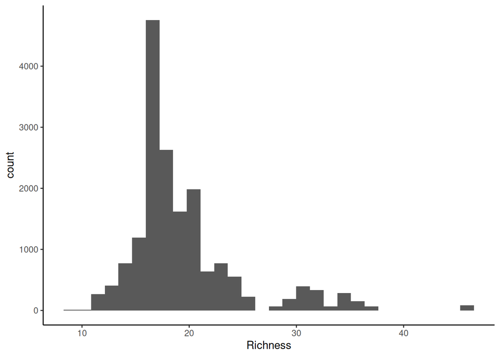

```r
hist <- toolik_plants %>%
  ggplot(aes(x = Richness))+
  geom_histogram()+
  theme_classic()
print(hist)
```

There are some other things we should think about. There are different types of numeric data here. For example, the years are whole numbers: we can’t have the year 2000.5.

The plant cover can be any value that is positive, it is therefore bounded at 0 and must be between 0 and 1. We can see this when we make a histogram of the data:

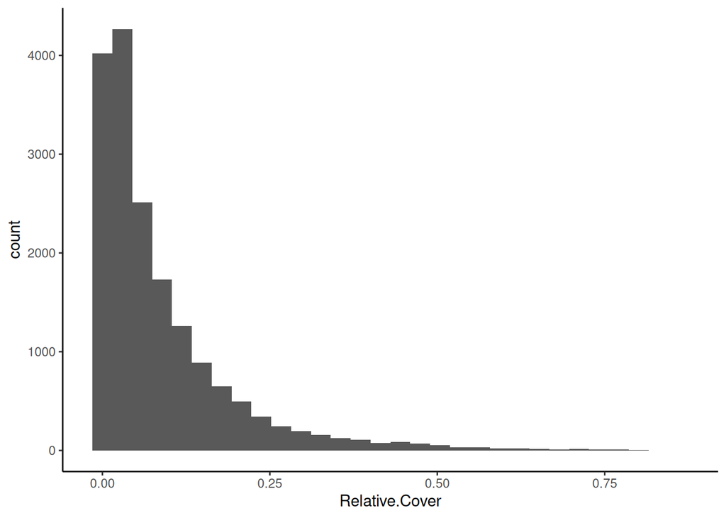

```r
hist2 <- toolik_plants %>%
  ggplot(aes(x = Relative.Cover))+
  geom_histogram()+
  theme_classic()
print(hist2)
```

## 4. Thinking about our experimental design

In the Toolik dataset of plant cover, we have both spatial and temporal replication. The spatial replication is on three different levels: there are multiple sites, which have multiple blocks within them and each block has eight plots. The temporal replication refers to the different years in which plant cover was recorded: four years.

### Spatial autocorrelation

One of the assumptions of a model is that the data points are independent. In reality, that is very rarely the case. For example, plots that are closer to one another might be more similar, which may or may not be related to some of the drivers we’re testing, e.g. temperature.

### Temporal autocorrelation

Similarly, it’s possible that the data points in one year are not independent from those in the year before. For example, if a species was more abundant in the year 2000, that’s going to influence it’s abundance in 2001 as well.

## 5. Turn a question into a model

Let’s go back to our original question:

### Question 1: How has plant species richness changed over time at Toolik Lake?

What is our dependent and independent variable here? We could write out our base model in words:

Richness is a function of time.

In R, this turns into the code: richness ~ time.

Richness is our dependent (response) variable and time is our independent (predictor) variable ([see here for more details](https://en.wikipedia.org/wiki/Dependent_and_independent_variables)). This is our base model, but what other things do we need to account for? What would happen if we just modelled richness as a function of time without dealing with the other structure in our data? Let’s find out in the rest of the tutorial.

## 6. Learn about the different types of models

Before we get back to our dataset that we are designing a model for, let’s revisit some statistics basics.

**Here are some questions to consider.**

- What is the difference between a continuous and a categorical variable in a linear model?
- How many variables can you have in a model?
- Is it better to have one model with five variables or one model per variable? When do we choose variables?
- What is a fixed effect? What is a random effect?
- What is the most important result from a model output?
- Why does it matter which type of models we use?

## 7. General linear models

Model without any random effects:

```r
plant_m <- lm(Richness ~ I(Year-2007), data = toolik_plants)
summary(plant_m)
```

```
##
## Call:
## lm(formula = Richness ~ I(Year - 2007), data = toolik_plants)
##
## Residuals:
##      Min       1Q   Median       3Q      Max
## -12.3266  -3.3266  -0.1138   1.9926  24.6734
##
## Coefficients:
##                Estimate Std. Error t value Pr(>|t|)
## (Intercept)    22.43296    0.07499  299.13   <2e-16 ***
## I(Year - 2007) -1.10639    0.02382  -46.44   <2e-16 ***
## ---
## Signif. codes:  0 '***' 0.001 '**' 0.01 '*' 0.05 '.' 0.1 ' ' 1
##
## Residual standard error: 4.985 on 17490 degrees of freedom
## Multiple R-squared:  0.1098, Adjusted R-squared:  0.1097
## F-statistic:  2157 on 1 and 17490 DF,  p-value: < 2.2e-16
```

Notice how we have transformed the Year column - I(Year - 2007) means that the year 2008 will become Year 1 - then your model is estimating richness across the first, second, etc., year from your survey period. Otherwise, if we had kept the years just as 2008, 2009,…, the model would have estimated richness really far back into the past, starting from Year 1, Year 2… Year 1550 up until 2012. This would make the magnitude of the estimates we get wrong. You can experiment to see what happens if we just add in Year - suddenly the slope of species change goes in the hundreds!

**Assumptions made:** + The data are normally distributed. + The data points are independent of one another. + The relationship between the variables we are studying is actually linear.

And there are many more - you can check out [this useful website](https://r-statistics.co/Assumptions-of-Linear-Regression.html) for the full list with examples and how to check if those are assumptions are met later.

Do you think the assumptions of a general linear model are met for our questions and data? Probably not!

We know that because of how the experimental design was set up (remember the Russian doll of plots within blocks within sites), the data points are not independent from one another. If we don’t account for the plot, block and site-level effects, we are completely ignoring the hierarchical structure of our data, which might then lead to wrong inferences based on the wrong model outputs.

### What is model convergence?

Model convergence is whether or not the model has worked, whether it has estimated your response variable (and random effects, see below) - basically whether the underlying mathematics have worked or have “broken” in some way. When we fit more complicated models, then we are pushing the limits of the underlying mathematics and things can go wrong, so it is important to check that your model did indeed work and that the estimates that you are making do make sense in the context of your raw data and the question you are asking/hypotheses that you are testing.

Checking model convergence can be done at different levels. With parametric models, good practice is to check the residual versus predicted plots. Using Bayesian approaches, there are a number of plots and statistics that can be assessed to determine model convergence. See below and in the Coding Club [MCMCglmm tutorial](https://ourcodingclub.github.io/tutorials/mcmcglmm/index.html). For an advanced discussion of model convergence, check out model [convergence in lme4](https://rdrr.io/cran/lme4/man/convergence.html).

For now, let’s check the residual versus predicted plot for our linear model. By using the ‘plot()’ function, we can plot the residuals versus fitted values, a Q-Q plot of standardised residuals, a scale-location plot (square roots of standardiaed residuals versus fitted values) and a plot of residuals versus leverage that adds bands corresponding to Cook’s distances of 0.5 and 1. Looking at these plots can help you identify any outliers that have huge leverage and confirm that your model has indeed run e.g. you want the data points on the Q-Q plot to follow the one-to-one line.

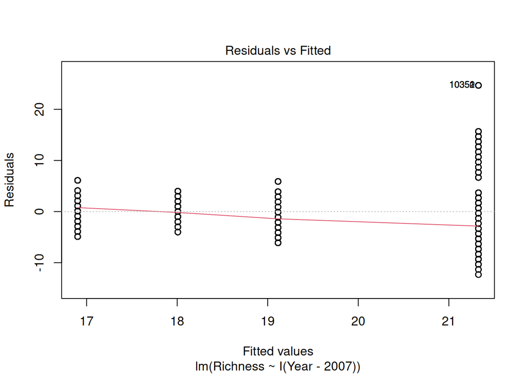

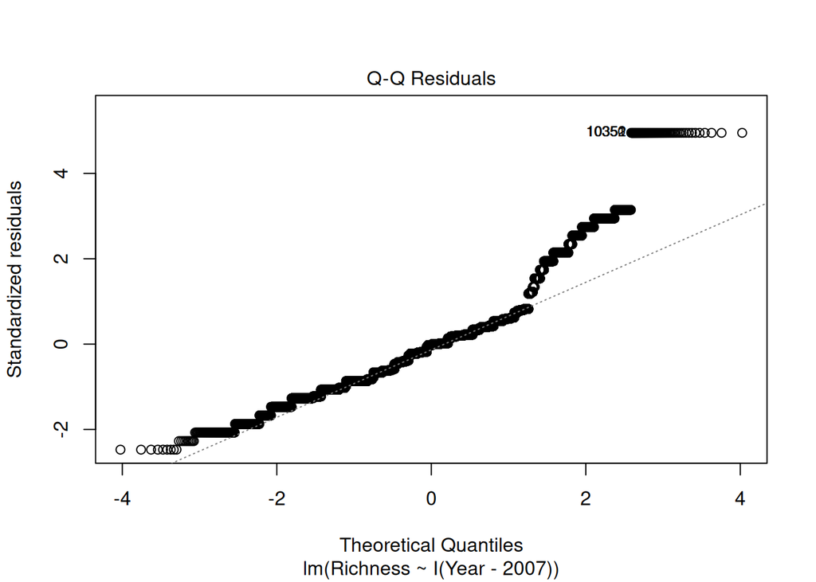

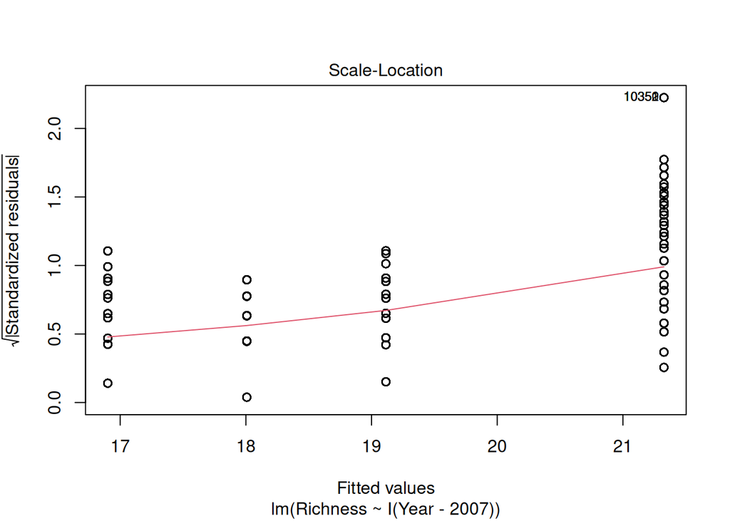

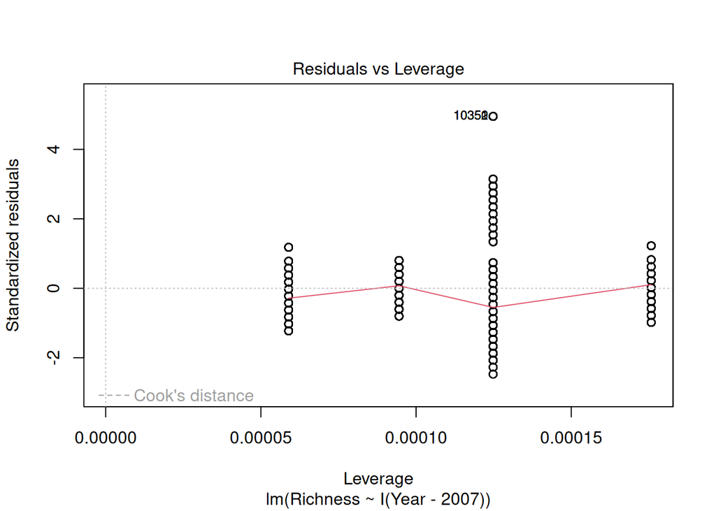

```r
plot(plant_m)
```

## 8. Hierarchical models using lme4

Now that we have explored the idea of a hierarchical model, let’s see how our analysis changes if we do or do not incorporate elements of the experimental design to the hierarchy of our model.

First, let’s model with only site as a random effect. This model does not incorporate the temporal replication in the data or the fact that there are plots within blocks within those sites.

```r
plant_m_plot <- lmer(Richness ~ I(Year-2007) + (1|Site), data = toolik_plants)
summary(plant_m_plot)
```

```
## Linear mixed model fit by REML ['lmerMod']
## Formula: Richness ~ I(Year - 2007) + (1 | Site)
##    Data: toolik_plants
##
## REML criterion at convergence: 75065.7
##
## Scaled residuals:
##     Min      1Q  Median      3Q     Max
## -3.5080 -0.5247 -0.0405  0.5907  6.3147
##
## Random effects:
##  Groups   Name        Variance Std.Dev.
##  Site     (Intercept) 52.506   7.246
##  Residual              4.266   2.065
## Number of obs: 17492, groups:  Site, 5
##
## Fixed effects:
##                Estimate Std. Error t value
## (Intercept)    21.50912    3.24073   6.637
## I(Year - 2007) -0.69628    0.01153 -60.392
##
## Correlation of Fixed Effects:
##             (Intr)
## I(Yer-2007) -0.007
```

From the summary() outputs, you can see the effect sizes (under the column “Estimate” in the “Fixed effects” part of the summary), a key element of the model outputs. Effect sizes tell us about the strengths of the relationships we are testing. In this model, the “Year” variable has an effect of about -0.7 on “Richness”, which can be interpreted as an annual decrease of 0.7 species.

We are still not accounting for the different plots and blocks though, so let’s gradually add those and see how the results change.

```r
plant_m_plot2 <- lmer(Richness ~ I(Year-2007) + (1|Site/Block), data = toolik_plants)
summary(plant_m_plot2)
```

```
## Linear mixed model fit by REML ['lmerMod']
## Formula: Richness ~ I(Year - 2007) + (1 | Site/Block)
##    Data: toolik_plants
##
## REML criterion at convergence: 70904.4
##
## Scaled residuals:
##     Min      1Q  Median      3Q     Max
## -2.7023 -0.6053 -0.0301  0.5783  7.1393
##
## Random effects:
##  Groups     Name        Variance Std.Dev.
##  Block:Site (Intercept)  3.660   1.913
##  Site       (Intercept) 55.970   7.481
##  Residual                3.345   1.829
## Number of obs: 17492, groups:  Block:Site, 19; Site, 5
##
## Fixed effects:
##                Estimate Std. Error t value
## (Intercept)    21.15511    3.37565   6.267
## I(Year - 2007) -0.72027    0.01023 -70.389
##
## Correlation of Fixed Effects:
##             (Intr)
## I(Yer-2007) -0.006
```

Have the estimates for the effect sizes changed?

```r
plant_m_plot3 <- lmer(Richness ~ I(Year-2007) + (1|Site/Block/Plot), data = toolik_plants)
summary(plant_m_plot3)
```

```
## Linear mixed model fit by REML ['lmerMod']
## Formula: Richness ~ I(Year - 2007) + (1 | Site/Block/Plot)
##    Data: toolik_plants
##
## REML criterion at convergence: 56055.7
##
## Scaled residuals:
##     Min      1Q  Median      3Q     Max
## -2.9486 -0.6082 -0.0070  0.6157  2.7458
##
## Random effects:
##  Groups          Name        Variance Std.Dev.
##  Plot:Block:Site (Intercept)  3.394   1.842
##  Block:Site      (Intercept)  3.254   1.804
##  Site            (Intercept) 55.114   7.424
##  Residual                     1.376   1.173
## Number of obs: 17492, groups:  Plot:Block:Site, 152; Block:Site, 19; Site, 5
##
## Fixed effects:
##                 Estimate Std. Error  t value
## (Intercept)    21.017985   3.350257    6.274
## I(Year - 2007) -0.704676   0.006793 -103.730
##
## Correlation of Fixed Effects:
##             (Intr)
## I(Yer-2007) -0.004
```

This final model answers our question about how plant species richness has changed over time, whilst also accounting for the hierarchical structure of the data.

Let’s check our model’s “fitted vs residuals” plot.

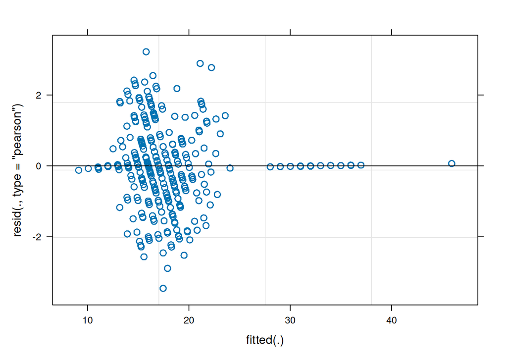

```r
plot(plant_m_plot3)
```

The points on this graph are evenly distributed on both sides of the horizontal line, which is a good sign that the model residuals do not violate the assumptions of the linear models.

Let’s visualise the results using the `sjPlot` package!

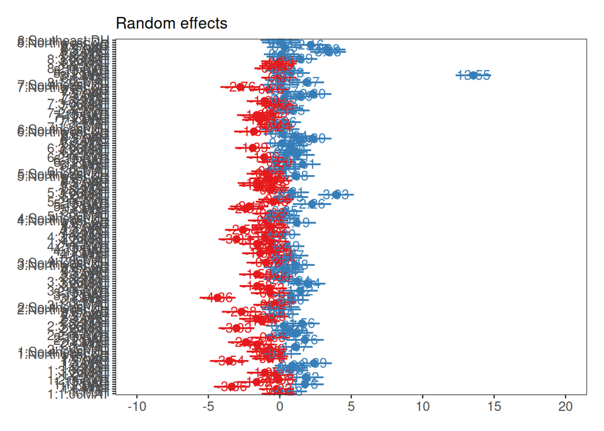

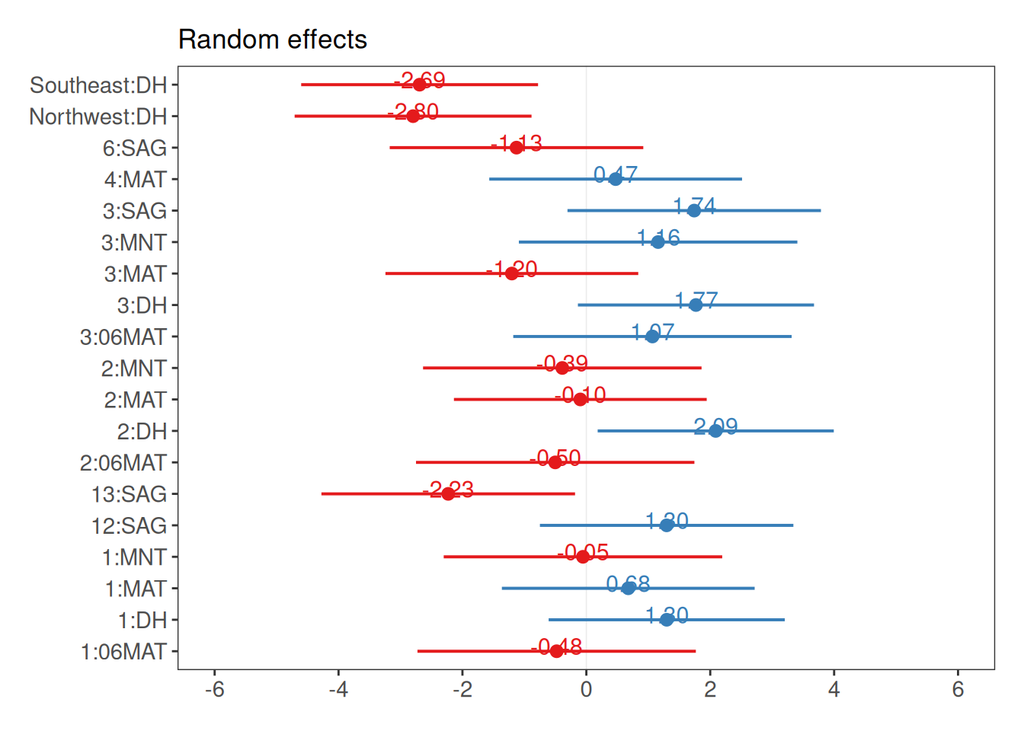

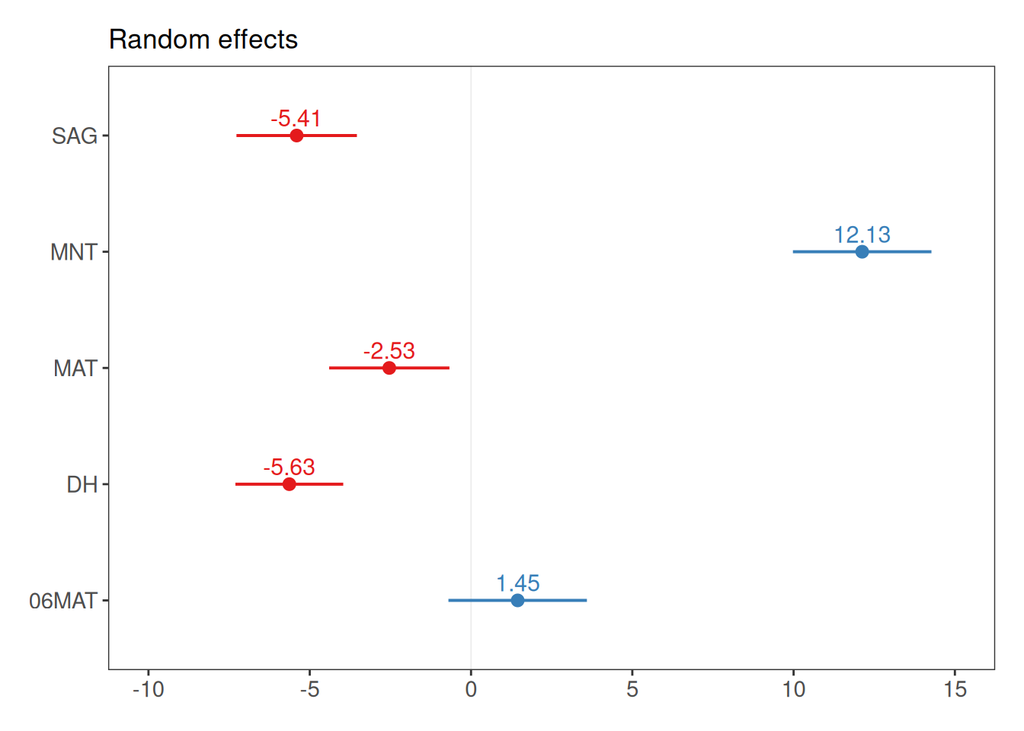

```r
# set a clean theme for the graphs
set_theme(base = theme_bw() +
            theme(panel.grid.major.x = element_blank(),
                  panel.grid.minor.x = element_blank(),
                  panel.grid.minor.y = element_blank(),
                  panel.grid.major.y = element_blank(),
                  plot.margin = unit(c(0.5, 0.5, 0.5, 0.5), units = , "cm")))

# Visualises random effects
re.effects <- plot_model(plant_m_plot3, type = 're', show.values = TRUE)
re.effects
```

Let’s visualise our fixed effects:

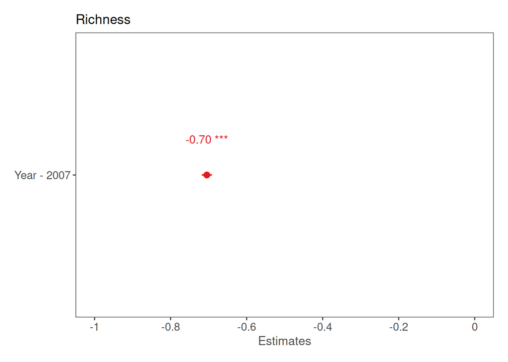

```r
# To see the estimate for our fixed effect (default): Year
fe.effects <- plot_model(plant_m_plot3, show.values = TRUE)
fe.effects
```

Since we only have one fixed effect in this model (Year), the graph produced shows the estimate for that effect size (the point) and the confidence interval (line around the point).

Now, let’s look at the effect of mean temperature on richness. We will use the same hierarchical structure for site/block/plot random effects. We will also add year as random effect this time.

```r
plant_m_temp <- lmer(Richness ~ Mean.Temp + (1|Site/Block/Plot) + (1|Year), data = toolik_plants)
summary(plant_m_temp)
```

```
## Linear mixed model fit by REML ['lmerMod']
## Formula: Richness ~ Mean.Temp + (1 | Site/Block/Plot) + (1 | Year)
##    Data: toolik_plants
##
## REML criterion at convergence: 55791.9
##
## Scaled residuals:
##      Min       1Q   Median       3Q      Max
## -2.94948 -0.59660 -0.00431  0.59339  2.52921
##
## Random effects:
##  Groups          Name        Variance Std.Dev.
##  Plot:Block:Site (Intercept)  3.395   1.843
##  Block:Site      (Intercept)  3.287   1.813
##  Site            (Intercept) 55.053   7.420
##  Year            (Intercept)  1.086   1.042
##  Residual                     1.354   1.163
## Number of obs: 17492, groups:
## Plot:Block:Site, 152; Block:Site, 19; Site, 5; Year, 4
##
## Fixed effects:
##             Estimate Std. Error t value
## (Intercept)   31.193      9.288   3.358
## Mean.Temp      1.447      1.006   1.439
##
## Correlation of Fixed Effects:
##           (Intr)
## Mean.Temp 0.931
## optimizer (nloptwrap) convergence code: 0 (OK)
## unable to evaluate scaled gradient
## Model failed to converge: degenerate  Hessian with 1 negative eigenvalues
```

Let’s look at the fixed effect first this time:

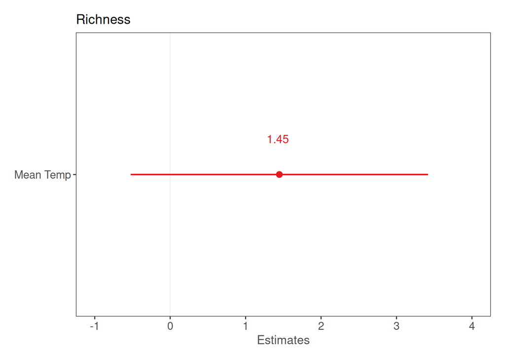

```r
# Visualise the fixed effect
temp.fe.effects <- plot_model(plant_m_temp, show.values = TRUE)
temp.fe.effects
```

The very wide confidence interval this time suggest high uncertainty about the effect of temperature on richness.

And the random effects:

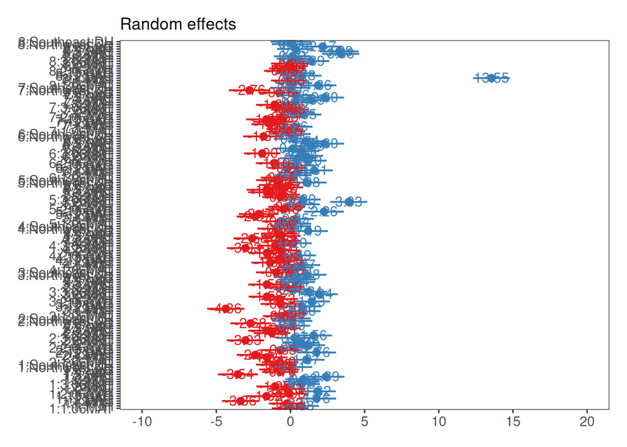

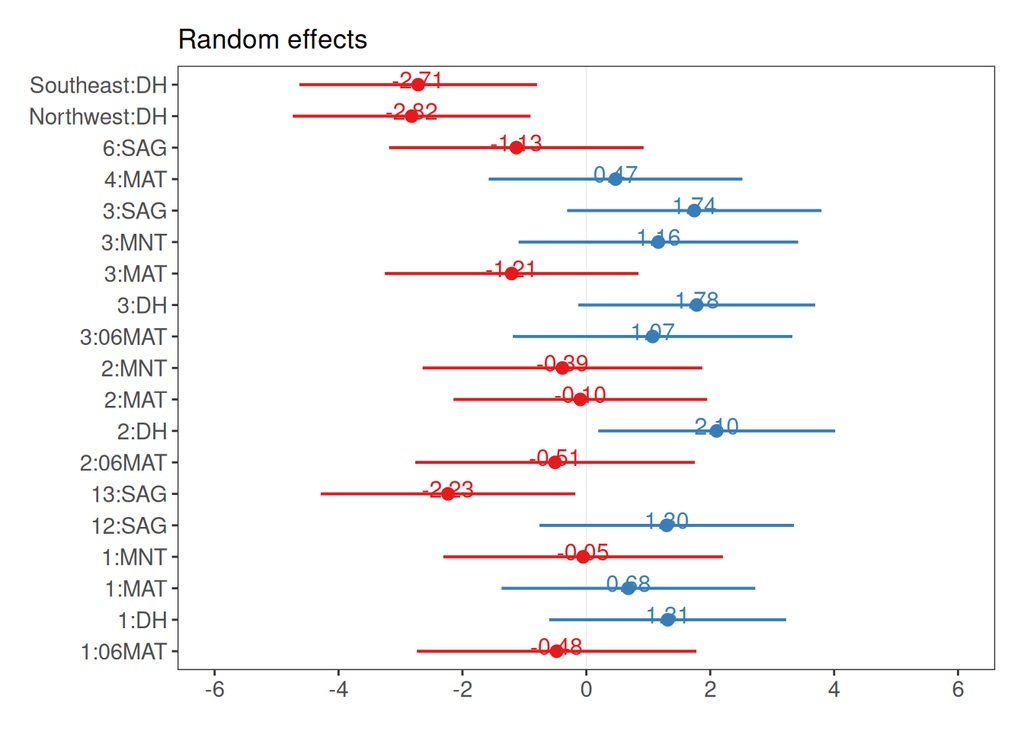

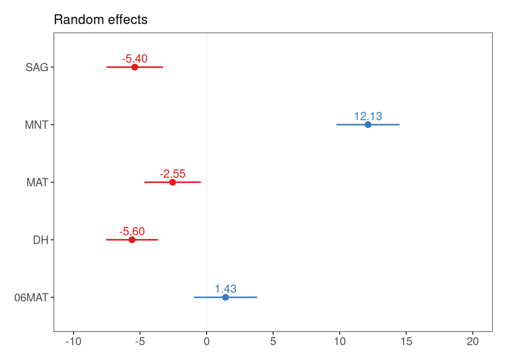

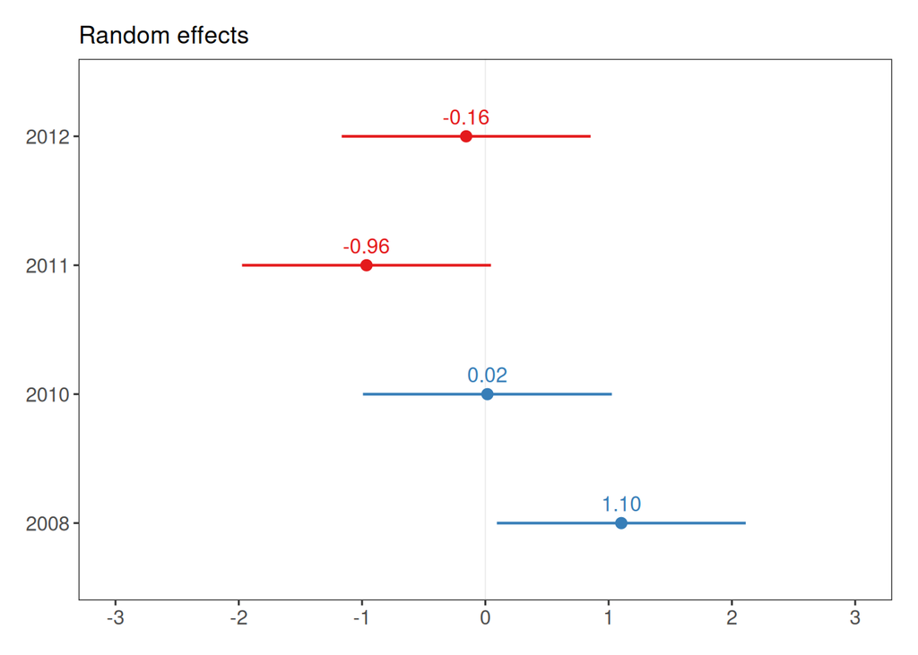

```r
# Visualise the tandom effect terms
temp.re.effects <- plot_model(plant_m_temp, type = 're', show.values = TRUE)
temp.re.effects
```

Assumptions made:

- The data are normally distributed.
- The data points are independent of one another.
- The relationship between the variables we are studying is actually linear.
- Plots represent the spatial replication and years represent the temporal replication in our data.

Assumptions not accounted for:

- We have not accounted for spatial autocorrelation in the data - whether more closely located plots are more likely to show similar responses than farther away plots.
- We have not accounted for temporal autocorrelation in the data - whether the influence of prior years of data are influencing the data in a given year.

## 9. Random slopes versus random intercepts lme4

We can now think about having random slopes and random intercepts. For our question, how does temperature influence species richness, we can allow each plot to have it’s own relationship with temperature.

```r
# Commented out because it does not converge.
if (FALSE){
  plant_m_rs <- lmer(Richness ~ Mean.Temp + (Mean.Temp|Site/Block/Plot) + (1|Year), data = toolik_plants)
  summary(plant_m_rs)
}
```

Check out the summary outputs and the messages we get. This model is not converging and we shouldn’t trust its outputs: the model structure is too complicated for the underlying data, so now we can simplify it.

If the code is running for a while, feel free to click on the “Stop” button and continue with the tutorial, as the model is not going to converge.

```r
plant_m_rs <- lmer(Richness ~ Mean.Temp + (Mean.Temp|Site) + (1|Year), data = toolik_plants)
summary(plant_m_rs)
```

```
## Linear mixed model fit by REML ['lmerMod']
## Formula: Richness ~ Mean.Temp + (Mean.Temp | Site) + (1 | Year)
##    Data: toolik_plants
##
## REML criterion at convergence: 74545.2
##
## Scaled residuals:
##     Min      1Q  Median      3Q     Max
## -3.3175 -0.6126 -0.0929  0.6167  6.4136
##
## Random effects:
##  Groups   Name        Variance Std.Dev. Corr
##  Site     (Intercept) 3864.650 62.166
##           Mean.Temp     44.293  6.655   1.00
##  Year     (Intercept)    1.344  1.159
##  Residual                4.135  2.033
## Number of obs: 17492, groups:  Site, 5; Year, 4
##
## Fixed effects:
##             Estimate Std. Error t value
## (Intercept)   30.420     30.019   1.013
## Mean.Temp      1.318      3.260   0.404
##
## Correlation of Fixed Effects:
##           (Intr)
## Mean.Temp 0.999
```

This time the model converges, but keep in mind that we are ignoring the hierarchical structure below “Site”, and therefore violating about assumption about independent data points (data below the “Site” level are actually grouped). But we will use it to show you what random-slopes models look like.

We can visualise the results:

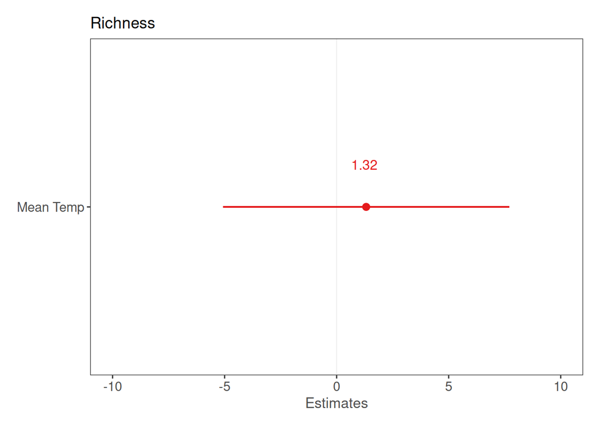

```r
plant.fe.effects <- plot_model(plant_m_rs, show.values = TRUE)
print(plant.fe.effects)
```

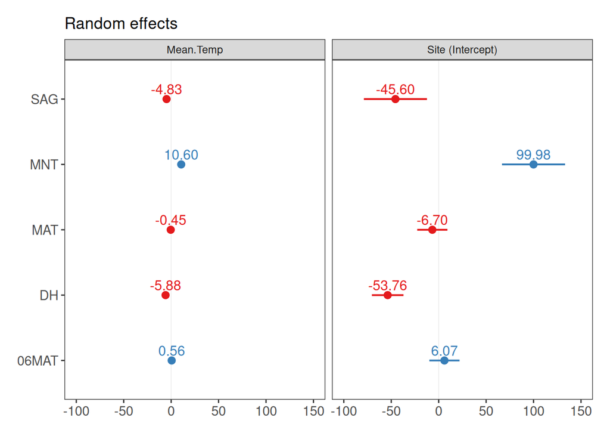

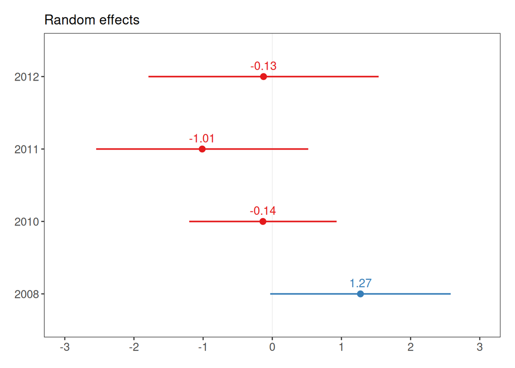

```r
plant.re.effects <- plot_model(plant_m_rs, type = 're', show.values = TRUE)
print(plant.re.effects)
```

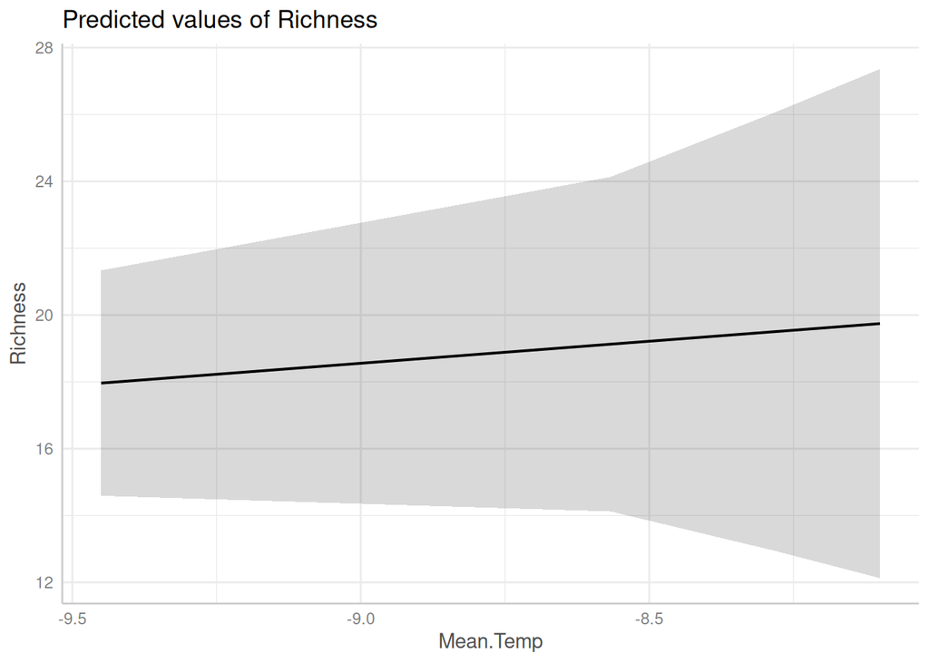

```r
ggpredict(plant_m_rs, terms = c('Mean.Temp')) %>% plot()
```

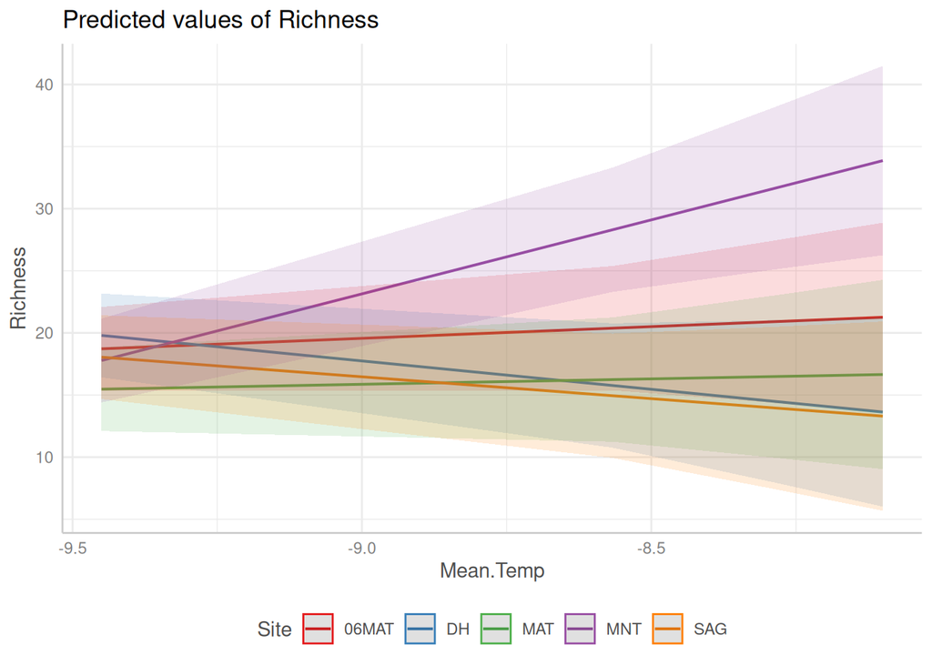

```r
ggpredict(plant_m_rs, terms = c('Mean.Temp', 'Site'), type = 'random') %>%
  plot()+
  theme(legend.position = 'bottom')
```

### An important note about honest graphs!

Interestingly, the default options from the `ggpredict()` function set the scale differently for the y axes on the two plots. If you just see the first plot, at a first glance you’d think that species richness is increasing a lot as temperature increases! But take note of the y axis: it doesn’t actually start at zero, thus the relationship is shown to be way stronger than it actually is.

We can manually plot the predictions to overcome this problem.

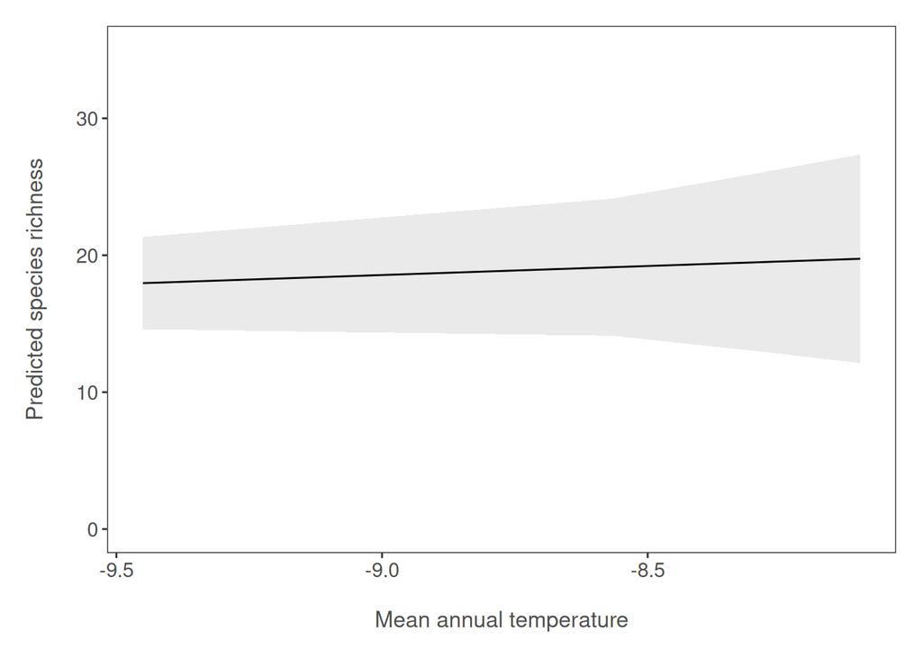

```r
# Overall predictions - note that we have specified just mean temperature as a term
predictions <- ggpredict(plant_m_rs, terms = c('Mean.Temp'))

pred_plot1 <- ggplot(predictions, aes(x, predicted))+
  geom_line()+
  geom_ribbon(aes(ymin = conf.low, ymax = conf.high), alpha = .1)+
  scale_y_continuous(limits = c(0, 35))+
  labs(x = '\nMean annual temperature', y = 'Predicted species richness\n')
print(pred_plot1)
```

The relationship between temperature and species richness doesn’t look that strong anymore! In fact, we see pretty small increases in species richness as temperature increases. What does that tell you about our hypothesis?

Now we can do the same, but this time taking into account the random effect.

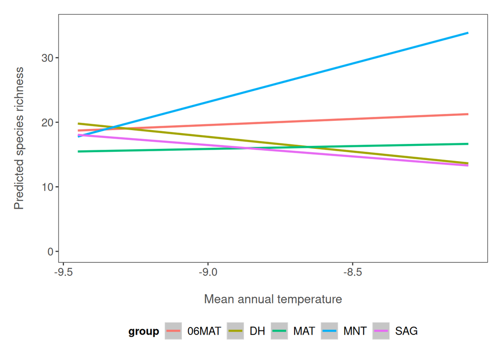

```r
# Predictions for each grouping level (here plot which is a random effect)
# re stands for random effect
predictions_rs_ri <- ggpredict(plant_m_rs, terms = c('Mean.Temp', 'Site'), type = 'random')

pred_plot_2 <- ggplot(predictions_rs_ri, aes(x, predicted, color = group))+
  stat_smooth(method = 'lm', se = TRUE)+
  scale_y_continuous(limits = c(0, 35))+
  theme(legend.position = 'bottom')+
  labs(x = '\nMean annual temperature', y = 'Predicted species richness\n')
plot(pred_plot_2)
```

Just for the sake of really seeing the random intercepts and random slopes, here is a zoomed in version), but note that when preparing graphs for reports or publications, your axes should start at zero to properly visualise the magnitude of the shown relationship.

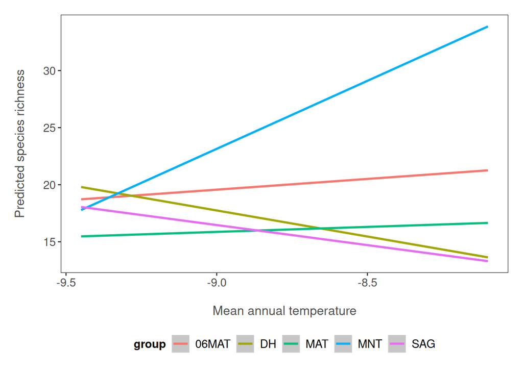

```r
pred_plot3 <- ggplot(predictions_rs_ri, aes(x, predicted, color = group))+
  stat_smooth(method = 'lm', se = TRUE)+
  theme(legend.position = 'bottom')+
  labs(
    x = "\nMean annual temperature",
    y = "Predicted species richness\n"
  )
plot(pred_plot3)
```

## 10. Hierarchical models using `MCMCglmm`

Let’s take our `lme4` model and explore what that model structure looks like in MCMCglmm. MCMCglmm fits Generalised Linear Mixed-effects Models using a Markov chain Monte Carlo approach under a Bayesian statistical framework.

To learn more about hierarchical models using MCMCglmm, you can check out our tutorial here, which has more details on the different model structures you can have and also provides an explanation of what priors are and how to set them in MCMCglmm.

For now, we can proceed knowing that just like in lme4, in MCMCglmm, we can add random and fixed effects to account for the structure of the data we are modelling. In MCMCglmm, there is greater flexibility in terms of specifying priors - that is, you can give your model additional information that is then taken into account when the model runs. For example, there might be some lower and upper bound limit for our response variable - e.g. we probably won’t find more than 1000 species in one small plant plot and zero is the lowest species richness can ever be.

Let’s explore how the model looks if we include Block and Plot as random effects (here they are random intercepts).

```r
plant_mcmc <- MCMCglmm(
  Richness ~ I(Year - 2007),
  random = ~Block + Plot,
  family = 'poisson',
  data = toolik_plants
)
```

```
## Warning: Unknown or uninitialised column: `family`.
```

[output not shown]

The model has ran, we have seen the many iterations roll down the screen, but what are the results and has the model really worked? Just like with other models, we can use summary() to see a summary of the model outputs.

```r
summary(plant_mcmc)
```

```
##
##  Iterations = 3001:12991
##  Thinning interval  = 10
##  Sample size  = 1000
##
##  DIC: 100340.3
##
##  G-structure:  ~Block
##
##       post.mean l-95% CI u-95% CI eff.samp
## Block    0.1027  0.02815   0.2305     1000
##
##                ~Plot
##
##      post.mean  l-95% CI u-95% CI eff.samp
## Plot 0.0009329 0.0001711 0.002164     1000
##
##  R-structure:  ~units
##
##       post.mean l-95% CI u-95% CI eff.samp
## units  0.004595  0.00385  0.00545    25.93
##
##  Location effects: Richness ~ I(Year - 2007)
##
##                post.mean l-95% CI u-95% CI eff.samp  pMCMC
## (Intercept)      2.85412  2.66291  3.08175   1000.0 <0.001 ***
## I(Year - 2007)  -0.06510 -0.06753 -0.06283    167.7 <0.001 ***
## ---
## Signif. codes:  0 '***' 0.001 '**' 0.01 '*' 0.05 '.' 0.1 ' ' 1
```

The posterior mean (i.e., the slope) for the Year term is -0.07 (remember that this is on the logarithmic scale, because we have used a Poisson distribution). So in general, based on this model, species richness has declined over time.

Now we should check if the model has converged. In MCMCglmm, we assess that using trace plots. You want them to look like a fuzzy caterpillar. Sol refers to the fixed effects and VCV to the random effects. Ours really don’t give off that fuzzy caterpillar vibe! So in this case, even though the model ran and we got our estimates, we wouldn’t really trust this model. This model is therefore not really the best model to answer our research question, because we are not accounting for the site effects, or for the fact that the plots are within blocks within sites.

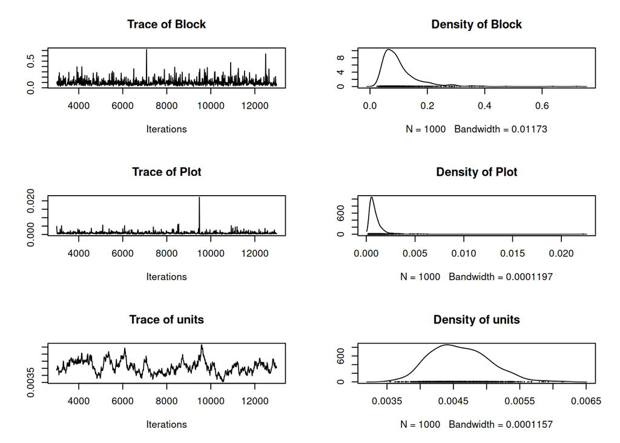

```r
plot(plant_mcmc$VCV)
```

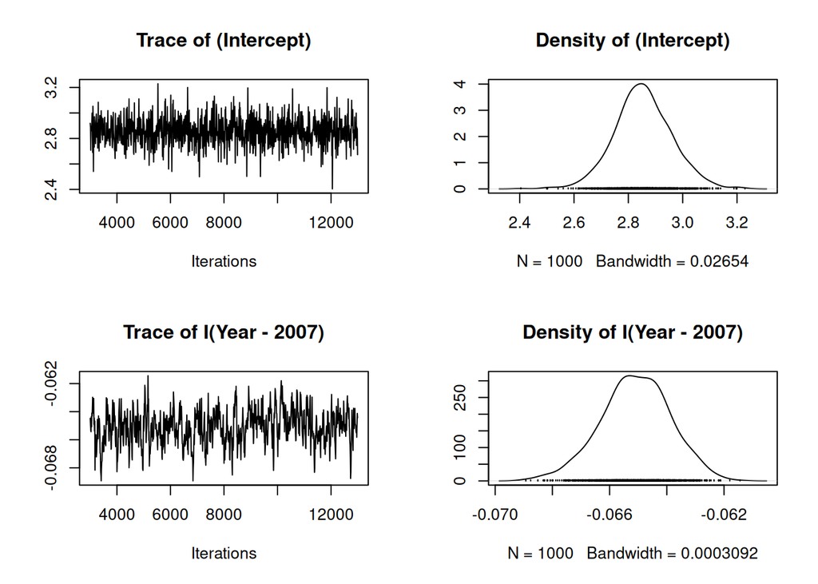

```r
plot(plant_mcmc$Sol)
```

Let’s see what the MCMCglmm models are like when we estimate changes in the cover of one species - Betula nana, dwarf birch. We can also use a Poisson distribution here, as we can think about plant cover as proportion data, e.g., Betula nana cover say 42% of our sample plot. There might be other suitable distributions like a beta binomial distribution, which we will explore in the sequel to this tutorial, coming to you soon!

We have added code for parameter-expanded priors. You don’t need to worry about the details of those, as in this tutorial we are thinking about the design of the model. These priors will improve model convergence and if you want to find out more about them, you can check out the MCMCglmm tutorial here.

```r
# Set weakly informative priors
prior2 <- list(R = list(V = 1, nu = 0.002),
               G = list(G1 = list(V = 1, nu = 1, alpha.mu = 0, alpha.v = 10000),
                        G2 = list(V = 1, nu = 1, alpha.mu = 0, alpha.v = 10000),
                        G3 = list(V = 1, nu = 1, alpha.mu = 0, alpha.v = 10000)))

# Extract just the Betula nana data
betula <- filter(toolik_plants, Species == "Bet nan")

betula_m <- MCMCglmm(
  round(Relative.Cover*100) ~ Year,
  random = ~Site + Block + Plot,
  family = 'poisson',
  prior = prior2,
  data = betula
)
```

[output not shown]

```r
summary(betula_m)
```

```
##
##  Iterations = 3001:12991
##  Thinning interval  = 10
##  Sample size  = 1000
##
##  DIC: 8632.541
##
##  G-structure:  ~Site
##
##      post.mean l-95% CI u-95% CI eff.samp
## Site      3.43   0.1767    10.03    700.4
##
##                ~Block
##
##       post.mean l-95% CI u-95% CI eff.samp
## Block    0.3305  0.06067   0.7546     1000
##
##                ~Plot
##
##      post.mean l-95% CI u-95% CI eff.samp
## Plot    0.1761  0.04031   0.4185    635.1
##
##  R-structure:  ~units
##
##       post.mean l-95% CI u-95% CI eff.samp
## units    0.4072   0.3664   0.4442     1089
##
##  Location effects: round(Relative.Cover * 100) ~ Year
##
##              post.mean   l-95% CI   u-95% CI eff.samp pMCMC
## (Intercept)  -7.078818 -67.492227  44.807587    892.0 0.826
## Year          0.004729  -0.021500   0.034252    891.2 0.766
```

[figure not shown]

```r
plot(betula_m$VCV)
```

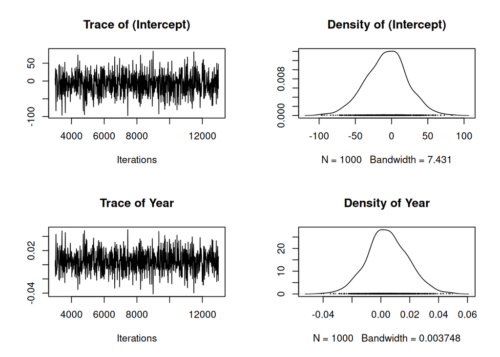

```r
plot(betula_m$Sol)
```

From the summary, we can see that the effect size for year is very small: it doesn’t look like the cover of Betula nana has changed much over the 2008-2012 survey period.

The trace plots for this model are a bit better than the previous one and we have included all three levels of our experimental hierarchy as random intercepts. We have ran these models with the default number of iteratations (13000). Increasing the number of iterations can improve convergence, so that’s something you can explore later if you want (you can increase the iterations by adding nitt = 100000 or a different number of your choice inside the MCMClgmm() code).

### Visualise model outputs

We can use the package MCMCvis by Casey Youngflesh to plot the results of our Betula nana model.

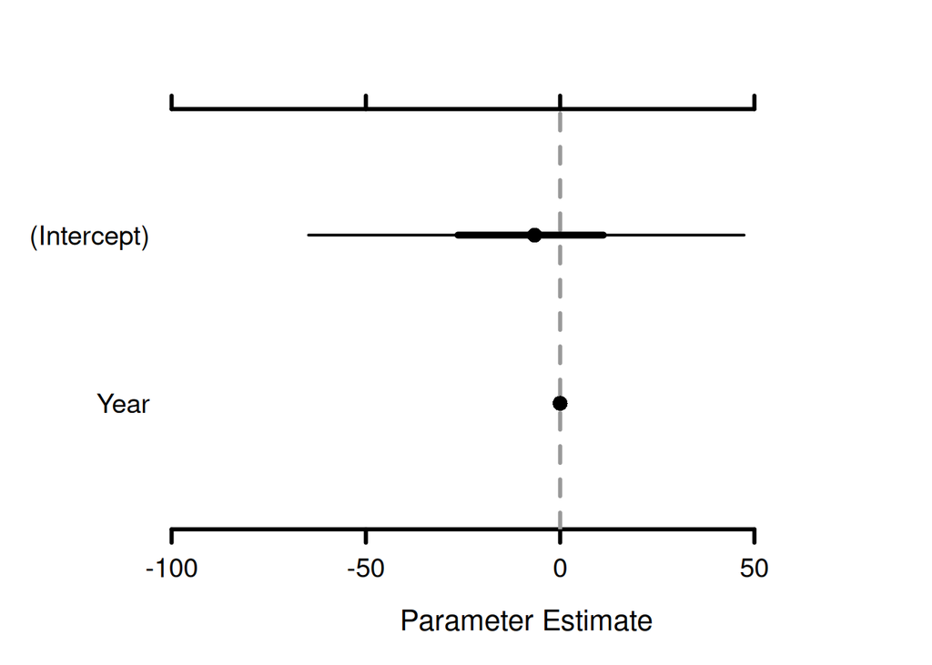

```r
MCMCplot(betula_m$Sol)
```

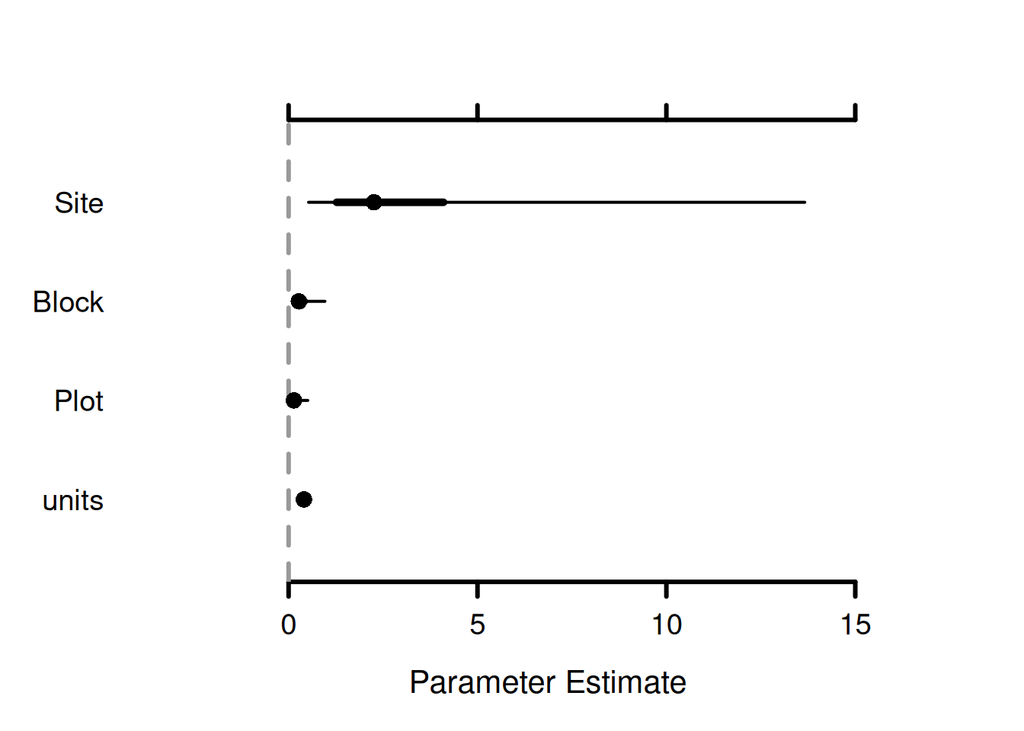

```r
MCMCplot(betula_m$VCV)
```

Sol refers to the fixed effects and VCV to the random effects, so we can see the effect sizes of the different variables we have added to our models. If the credible intervals overlap zero, then those effects are not significant, so we can see here that Betula nana cover hasn’t changed. units refers to the residual variance.

## Conclusions

Today we have learned that in order to design a statistical model, we first need to think about our questions, the structure in the data we are working with and the types of assumptions that we want to make. No model will ever be perfect, but we can use hierarchical models to minimize the assumptions that we are making about our data and to better represent the complex data structures that we often have in ecology and other disciplines. Designing a statistical model can at first seem very overwhelming, but it gets easier over time and in the end, can be one of the most fun bits of ecology, believe it or not! And the more tools you build in your statistical toolkit to help you developing appropriate statistical models, the better you will be able to tackle the challenges that ecological data throw your way! Happy modelling!

## Extras

If you are keen, you can now try out the brms package and generate the Stan code for this model. This will help us to start to think about how we can implement hierarchical models using the statistical programming language Stan.

> Important: this bit of the tutorial is skipped as there are references to other courses that I plan to go over at a different time.